# Spotify Hit Maker Analysis

Nishant Lokesh

# 1. Introduction (The Business Case)

## 1.1 Problem Statement

The music industry is expensive and risky. Breaking a new artist can cost millions of dollars, and record labels still lean heavily on “gut feeling” when deciding which songs to promote. In a streaming era dominated by algorithms and data, this guesswork can lead to wasted marketing spend on songs that do not match current listener preferences.

In this project, we tackle the problem of **how a record label can use data to understand what makes a popular Spotify song in 2020**. Without a clear picture of the “anatomy” of a hit, labels may be investing in tracks that are statistically unlikely to perform well.

## 1.2 Overview of Data and Methodology

To address this, we analyze a **Spotify songs dataset** that contains thousands of tracks with detailed audio features created by Spotify’s systems. These include variables such as:

- **danceability**
- **energy**
- **valence** (happiness)
- **acousticness**
- **speechiness**
- **tempo**
- **duration** in milliseconds
- **playlist_genre**
- **track_popularity** (0–100)

We will import and clean the data in R using the **tidyverse** and **lubridate** packages. Then we will explore how these audio features differ across genres and popularity levels. After EDA, we will apply statistical models to quantify what matters most.

## 1.3 Analytical Approach

Our analysis uses three modeling techniques:

1. **Linear regression**
   - Treats `track_popularity` as a continuous outcome.
   - Helps us see how features like danceability, energy, valence, tempo, and duration relate to popularity.
2. **Binary logistic regression**
   - We create a new variable `is_hit` that flags songs in the top 25% of popularity.
   - The model estimates the probability that a song becomes a “Hit” based on its audio features and genre.
3. **Decision tree (classification)**
   - Builds a tree that splits on variables like danceability and genre.
   - Gives simple “if/then” rules that decision-makers can interpret quickly.

## 1.4 Value for the Business

The goal is to give the record label a **data-driven checklist** for deciding which songs are most promising. Instead of signing artists blindly, they can use our findings to:

- Focus promotion on songs with features that historically align with hits.
- Provide concrete feedback to producers (e.g., “Our models suggest highly danceable Pop songs around a certain duration perform better.”).
- Reduce wasted marketing spend and increase the chance of getting songs onto playlists and charts.

# 2. Packages Required

```r
# Data wrangling and plotting
library(tidyverse)   # dplyr, ggplot2, etc. for manipulation and visualization
library(lubridate)   # working with dates (convert release date to year)

# Modeling and tidy model output
library(broom)       # turn model outputs into clean tables

# Decision trees
library(rpart)       # build classification/regression trees
library(rpart.plot)  # visualize decision trees

# Tables and formatting
library(knitr)       # kable() for simple tables
library(kableExtra)  # styling kable tables in HTML output
```

We use:

- **tidyverse** for data importing, cleaning, and visualization.
- **lubridate** to parse and extract dates (e.g., the release year).
- **broom** to convert regression and logistic regression results into clean tables.
- **rpart** and **rpart.plot** to build and visualize a decision tree model.
- **knitr** and **kableExtra** to present summary tables in a clear, readable format.

# 3. Data Preparation

## 3.1 Data Source

The dataset we use is a **Spotify songs dataset** containing track-level audio features and popularity scores. It is widely shared in data science communities and is derived from the Spotify Web API via tools such as the `spotifyr` R package and similar pipelines.

Each row represents one track with:

- track and artist identifiers
- playlist info (e.g., `playlist_genre`)
- audio features such as danceability, energy, valence, tempo, and duration
- a `track_popularity` score from 0 to 100

## 3.2 Import and Initial Description

```r
# Read the CSV file (make sure the file name and path are correct)
spotify_raw <- readr::read_csv("spotify_songs 2.csv")

# Quick overview of the raw data structure
glimpse(spotify_raw)
```

```
## Rows: 32,833
## Columns: 23
## $ track_id                 <chr> "6f807x0ima9a1j3VPbc7VN", "0r7CVbZTWZgbTCYdfa…
## $ track_name               <chr> "I Don't Care (with Justin Bieber) - Loud Lux…
## $ track_artist             <chr> "Ed Sheeran", "Maroon 5", "Zara Larsson", "Th…
## $ track_popularity         <dbl> 66, 67, 70, 60, 69, 67, 62, 69, 68, 67, 58, 6…
## $ track_album_id           <chr> "2oCs0DGTsRO98Gh5ZSl2Cx", "63rPSO264uRjW1X5E6…
## $ track_album_name         <chr> "I Don't Care (with Justin Bieber) [Loud Luxu…
## $ track_album_release_date <chr> "2019-06-14", "2019-12-13", "2019-07-05", "20…
## $ playlist_name            <chr> "Pop Remix", "Pop Remix", "Pop Remix", "Pop R…
## $ playlist_id              <chr> "37i9dQZF1DXcZDD7cfEKhW", "37i9dQZF1DXcZDD7cf…
## $ playlist_genre           <chr> "pop", "pop", "pop", "pop", "pop", "pop", "po…
## $ playlist_subgenre        <chr> "dance pop", "dance pop", "dance pop", "dance…
## $ danceability             <dbl> 0.748, 0.726, 0.675, 0.718, 0.650, 0.675, 0.4…
## $ energy                   <dbl> 0.916, 0.815, 0.931, 0.930, 0.833, 0.919, 0.8…
## $ key                      <dbl> 6, 11, 1, 7, 1, 8, 5, 4, 8, 2, 6, 8, 1, 5, 5,…
## $ loudness                 <dbl> -2.634, -4.969, -3.432, -3.778, -4.672, -5.38…
## $ mode                     <dbl> 1, 1, 0, 1, 1, 1, 0, 0, 1, 1, 1, 1, 1, 0, 0, …
## $ speechiness              <dbl> 0.0583, 0.0373, 0.0742, 0.1020, 0.0359, 0.127…
## $ acousticness             <dbl> 0.10200, 0.07240, 0.07940, 0.02870, 0.08030, …
## $ instrumentalness         <dbl> 0.00e+00, 4.21e-03, 2.33e-05, 9.43e-06, 0.00e…
## $ liveness                 <dbl> 0.0653, 0.3570, 0.1100, 0.2040, 0.0833, 0.143…
## $ valence                  <dbl> 0.518, 0.693, 0.613, 0.277, 0.725, 0.585, 0.1…
## $ tempo                    <dbl> 122.036, 99.972, 124.008, 121.956, 123.976, 1…
## $ duration_ms              <dbl> 194754, 162600, 176616, 169093, 189052, 16304…
```

The raw dataset contains many variables, including artist name, track name, playlist information, several audio features, and a popularity score. Some tracks are from multiple years and some may have missing or zero popularity.

## 3.3 Cleaning and Feature Engineering

For this business question, we focus on **songs released in 2020** and ensure popularity is meaningful. We:

- Convert the release date to a proper date and extract the **year**
- Create **duration in minutes**
- Filter to **year == 2020**
- Remove songs with `track_popularity == 0`
- Remove duplicate tracks (by `track_id`)
- Create a **binary hit variable** `is_hit` based on the top 25% of popularity

```r
spotify_clean <- spotify_raw %>%
  mutate(
    # Parse release date and extract year
    track_album_release_date = ymd(track_album_release_date),
    year = year(track_album_release_date),
    # Convert duration from milliseconds to minutes
    duration_min = duration_ms / 60000
  ) %>%
  # Keep only 2020 songs with non-zero popularity
  filter(
    year == 2020,
    track_popularity > 0
  ) %>%
  # Remove duplicate tracks
  distinct(track_id, .keep_all = TRUE)

# Store some summary numbers for inline use
n_songs_2020   <- nrow(spotify_clean)
avg_popularity <- mean(spotify_clean$track_popularity, na.rm = TRUE)
sd_popularity  <- sd(spotify_clean$track_popularity, na.rm = TRUE)

# Define hit cutoff as top 25% of popularity
hit_cutoff <- quantile(spotify_clean$track_popularity, 0.75, na.rm = TRUE)

spotify_clean <- spotify_clean %>%
  mutate(
    is_hit = if_else(track_popularity >= hit_cutoff, 1, 0),
    is_hit = factor(is_hit, levels = c(0, 1), labels = c("Flop", "Hit")),
    playlist_genre = factor(playlist_genre)
  )
```

After cleaning, we keep **625** unique songs released in 2020 with non-zero popularity. The average popularity in this subset is about **42.8**, with a standard deviation of about **17.9**. We define a song as a **“Hit”** if its popularity is at or above **54**, corresponding to the top 25% of 2020 songs.

## 3.4 Snapshot of Cleaned Data

```r
spotify_clean %>%
  select(
    track_name, track_artist, playlist_genre,
    track_popularity, danceability, energy, valence,
    acousticness, tempo, duration_min, is_hit
  ) %>%
  slice_head(n = 8) %>%
  kable(caption = "Sample of cleaned Spotify 2020 tracks with key features") %>%
  kable_styling(full_width = FALSE)
```

Sample of cleaned Spotify 2020 tracks with key features

[output not shown]

## 3.5 Summary of Key Variables

We first summarize by **hit status** (Hit vs Flop):

```r
hit_summary <- spotify_clean %>%
  group_by(is_hit) %>%
  summarise(
    n_songs        = n(),
    avg_popularity = mean(track_popularity),
    avg_dance      = mean(danceability),
    avg_energy     = mean(energy),
    avg_valence    = mean(valence),
    avg_tempo      = mean(tempo),
    avg_duration   = mean(duration_min),
    .groups = "drop"
  )

hit_summary %>%
  kable(digits = 2,
        caption = "Average audio features for hits vs flops (2020 songs)") %>%
  kable_styling(full_width = FALSE)
```

Average audio features for hits vs flops (2020 songs)

| is_hit | n_songs | avg_popularity | avg_dance | avg_energy | avg_valence | avg_tempo | avg_duration |
| --- | --- | --- | --- | --- | --- | --- | --- |
| Flop | 462 | 34.91 | 0.65 | 0.68 | 0.47 | 121.89 | 3.26 |
| Hit | 163 | 65.35 | 0.71 | 0.64 | 0.47 | 121.87 | 3.20 |

This table shows how hits differ from flops on average; for example, hits may be more danceable and slightly shorter than non-hit songs.

We can also summarize by **playlist genre**:

```r
genre_summary <- spotify_clean %>%
  group_by(playlist_genre) %>%
  summarise(
    n_songs        = n(),
    avg_popularity = mean(track_popularity),
    avg_dance      = mean(danceability),
    avg_energy     = mean(energy),
    avg_valence    = mean(valence),
    .groups = "drop"
  ) %>%
  arrange(desc(avg_popularity))

genre_summary %>%
  kable(digits = 2,
        caption = "Average popularity and audio features by playlist genre (2020)") %>%
  kable_styling(full_width = FALSE)
```

Average popularity and audio features by playlist genre (2020)

| playlist_genre | n_songs | avg_popularity | avg_dance | avg_energy | avg_valence |
| --- | --- | --- | --- | --- | --- |
| rap | 152 | 49.83 | 0.72 | 0.61 | 0.46 |
| pop | 165 | 46.20 | 0.64 | 0.63 | 0.47 |
| latin | 94 | 41.30 | 0.72 | 0.69 | 0.60 |
| r&b | 60 | 38.53 | 0.69 | 0.60 | 0.49 |
| rock | 41 | 37.10 | 0.47 | 0.85 | 0.42 |
| edm | 113 | 34.24 | 0.66 | 0.78 | 0.39 |

# 4. Analysis & Visuals

## 4.1 Scatter Plot: Valence vs Popularity

The rubric suggests a scatter plot of valence vs popularity with a trend line. We can also color points by hit status.

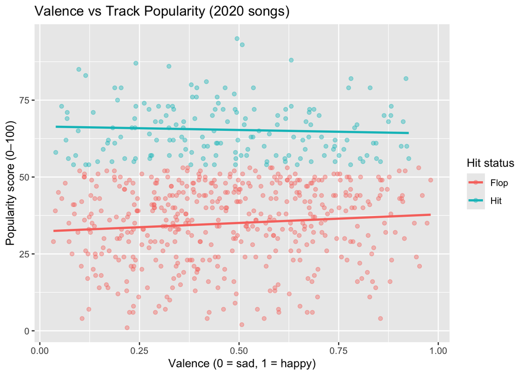

```r
ggplot(spotify_clean, aes(x = valence, y = track_popularity, color = is_hit)) +
  geom_point(alpha = 0.4) +
  geom_smooth(method = "lm", se = FALSE) +
  labs(
    title = "Valence vs Track Popularity (2020 songs)",
    x = "Valence (0 = sad, 1 = happy)",
    y = "Popularity score (0–100)",
    color = "Hit status"
  )
```

This plot helps us see whether happier songs (higher valence) tend to be more popular, and whether the relationship differs between hits and flops.

## 4.2 Correlation Matrix of Numeric Features

We create a correlation matrix of key numeric variables including popularity.

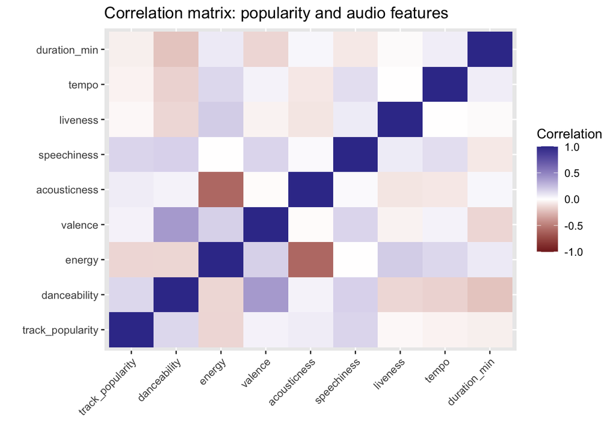

```r
corr_vars <- spotify_clean %>%
  select(
    track_popularity, danceability, energy, valence,
    acousticness, speechiness, liveness, tempo, duration_min
  )

corr_mat <- cor(corr_vars, use = "complete.obs")

corr_tbl <- as.data.frame(as.table(corr_mat))

ggplot(corr_tbl, aes(Var1, Var2, fill = Freq)) +
  geom_tile() +
  scale_fill_gradient2(limits = c(-1, 1)) +
  labs(
    title = "Correlation matrix: popularity and audio features",
    x = "",
    y = "",
    fill = "Correlation"
  ) +
  theme(axis.text.x = element_text(angle = 45, hjust = 1))
```

## 4.3 Linear Regression: Predicting Popularity

We first model `track_popularity` as a continuous outcome.

```r
lm_pop <- lm(
  track_popularity ~ danceability + energy + valence +
    acousticness + tempo + duration_min + playlist_genre,
  data = spotify_clean
)

lm_results <- broom::tidy(lm_pop)

lm_results %>%
  kable(digits = 3,
        caption = "Linear regression: predictors of track popularity") %>%
  kable_styling(full_width = FALSE)
```

Linear regression: predictors of track popularity

| term | estimate | std.error | statistic | p.value |
| --- | --- | --- | --- | --- |
| (Intercept) | 30.864 | 7.505 | 4.113 | 0.000 |
| danceability | 14.136 | 5.707 | 2.477 | 0.014 |
| energy | -6.006 | 5.128 | -1.171 | 0.242 |
| valence | -0.565 | 3.583 | -0.158 | 0.875 |
| acousticness | -2.728 | 3.686 | -0.740 | 0.460 |
| tempo | 0.002 | 0.026 | 0.086 | 0.932 |
| duration_min | -0.316 | 0.978 | -0.323 | 0.747 |
| playlist_genrelatin | 6.169 | 2.524 | 2.444 | 0.015 |
| playlist_genrepop | 11.796 | 2.241 | 5.263 | 0.000 |
| playlist_genrer&b | 3.201 | 2.862 | 1.119 | 0.264 |
| playlist_genrerap | 14.177 | 2.253 | 6.294 | 0.000 |
| playlist_genrerock | 5.877 | 3.324 | 1.768 | 0.078 |

We can also look at a quick model summary:

```r
summary(lm_pop)
```

```
##
## Call:
## lm(formula = track_popularity ~ danceability + energy + valence +
##     acousticness + tempo + duration_min + playlist_genre, data = spotify_clean)
##
## Residuals:
##     Min      1Q  Median      3Q     Max
## -39.018 -11.351  -0.432  11.513  48.270
##
## Coefficients:
##                      Estimate Std. Error t value Pr(>|t|)
## (Intercept)         30.864432   7.505002   4.113 4.45e-05 ***
## danceability        14.135759   5.706590   2.477   0.0135 *
## energy              -6.005843   5.127640  -1.171   0.2419
## valence             -0.564806   3.583035  -0.158   0.8748
## acousticness        -2.728001   3.685854  -0.740   0.4595
## tempo                0.002193   0.025558   0.086   0.9316
## duration_min        -0.316129   0.977668  -0.323   0.7465
## playlist_genrelatin  6.169418   2.524332   2.444   0.0148 *
## playlist_genrepop   11.795701   2.241142   5.263 1.96e-07 ***
## playlist_genrer&b    3.201014   2.861564   1.119   0.2637
## playlist_genrerap   14.176668   2.252524   6.294 5.91e-10 ***
## playlist_genrerock   5.877003   3.323601   1.768   0.0775 .
## ---
## Signif. codes:  0 '***' 0.001 '**' 0.01 '*' 0.05 '.' 0.1 ' ' 1
##
## Residual standard error: 16.95 on 613 degrees of freedom
## Multiple R-squared:  0.1168, Adjusted R-squared:  0.1009
## F-statistic: 7.368 on 11 and 613 DF,  p-value: 6.469e-12
```

## 4.4 Logistic Regression: Predicting Hit vs Flop

Next, we predict whether a song is a **Hit** (top 25% of popularity) or **Flop** using logistic regression.

```r
logit_hit <- glm(
  is_hit ~ danceability + energy + valence +
    acousticness + tempo + duration_min + playlist_genre,
  data = spotify_clean,
  family = binomial
)

logit_results <- broom::tidy(logit_hit) %>%
  mutate(odds_ratio = exp(estimate))

logit_results %>%
  kable(digits = 3,
        caption = "Logistic regression: odds of being a hit (top 25%)") %>%
  kable_styling(full_width = FALSE)
```

Logistic regression: odds of being a hit (top 25%)

| term | estimate | std.error | statistic | p.value | odds_ratio |
| --- | --- | --- | --- | --- | --- |
| (Intercept) | -4.150 | 1.093 | -3.798 | 0.000 | 0.016 |
| danceability | 3.120 | 0.851 | 3.667 | 0.000 | 22.644 |
| energy | -0.186 | 0.714 | -0.261 | 0.794 | 0.830 |
| valence | -0.811 | 0.499 | -1.626 | 0.104 | 0.444 |
| acousticness | -0.051 | 0.508 | -0.099 | 0.921 | 0.951 |
| tempo | 0.004 | 0.004 | 1.039 | 0.299 | 1.004 |
| duration_min | -0.001 | 0.136 | -0.006 | 0.995 | 0.999 |
| playlist_genrelatin | 0.802 | 0.406 | 1.975 | 0.048 | 2.230 |
| playlist_genrepop | 1.207 | 0.367 | 3.289 | 0.001 | 3.343 |
| playlist_genrer&b | 0.864 | 0.447 | 1.936 | 0.053 | 2.374 |
| playlist_genrerap | 1.556 | 0.358 | 4.344 | 0.000 | 4.739 |
| playlist_genrerock | 1.391 | 0.519 | 2.681 | 0.007 | 4.020 |

We can create a simple confusion matrix by classifying songs as “Hit” if predicted probability ≥ 0.5.

```r
spotify_clean <- spotify_clean %>%
  mutate(
    p_hit    = predict(logit_hit, type = "response"),
    pred_hit = if_else(p_hit >= 0.5, "Hit", "Flop")
  )

conf_mat <- table(
  Actual = spotify_clean$is_hit,
  Predicted = spotify_clean$pred_hit
)

conf_mat %>%
  kable(caption = "Confusion matrix for hit vs flop classification") %>%
  kable_styling(full_width = FALSE)
```

Confusion matrix for hit vs flop classification

|  | Flop | Hit |
| --- | --- | --- |
| Flop | 455 | 7 |
| Hit | 149 | 14 |

From the odds ratios, we can interpret effects in business terms, for example:

- A 0.1 increase in danceability might increase the odds of being a hit by some percentage (odds_ratio > 1).
- Certain genres (e.g., Pop or Rap) may significantly raise the odds of being a hit relative to a baseline genre.

## 4.5 Decision Tree: Simple Hit Rules

Finally, we build a decision tree to get simple, interpretable rules for hit songs.

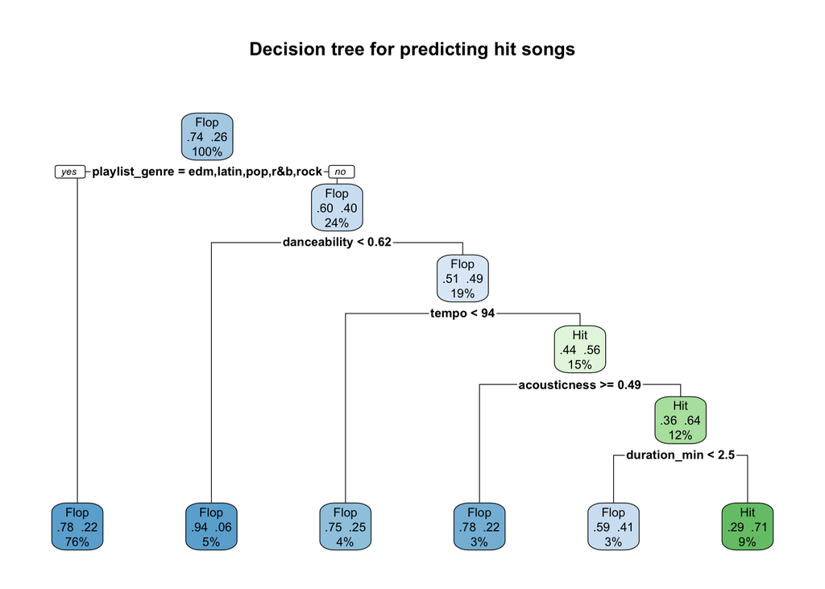

```r
set.seed(123)

tree_hit <- rpart(
  is_hit ~ danceability + energy + valence +
    acousticness + tempo + duration_min + playlist_genre,
  data = spotify_clean,
  method = "class",
  control = rpart.control(cp = 0.01, minsplit = 50)
)

rpart.plot(
  tree_hit,
  type = 2,
  extra = 104,
  fallen.leaves = TRUE,
  main = "Decision tree for predicting hit songs"
)
```

# 5. Summary, Insights, and Recommendations

## 5.1 Restating the Problem

We set out to help a record label **avoid blindly signing songs** by using Spotify audio data to understand what makes a popular song in 2020.

## 5.2 Approach Summary

We:

- Imported a Spotify songs dataset and cleaned it (filtering to 2020, removing zero-popularity tracks, creating duration in minutes, and defining a hit variable).
- Performed exploratory data analysis, including scatter plots and correlation analysis.
- Built three models: a linear regression for continuous popularity, a logistic regression for hit vs flop, and a decision tree to produce easy-to-interpret rules.

## 5.4 Implications for Decision-Makers

For the record label, this suggests:

- When evaluating new tracks, prioritize songs that are **highly danceable**, especially in **Pop** or **Rap** genres.
- Use the models as a **screening tool**—if a track scores low on key features that drive hits, it may be a riskier investment.
- Tailor production and promotion strategies by genre. For example, what works for Pop may not be ideal for R&B or Rock.

## 5.5 Limitations and Future Work

- The data is limited to songs around **2020**; listener preferences may change over time.
- We only use audio features and popularity; we do **not** include lyrics, artist fame, marketing budget, or social media buzz, all of which can influence success.
- Future work could:
  - Add text analysis of lyrics (sentiment, themes).
  - Include external data (e.g., TikTok trends, YouTube views).
  - Test more advanced models (random forests, gradient boosting) to improve predictive accuracy.

Overall, this analysis gives the label a **data-informed starting point** for selecting and shaping songs, replacing pure gut feeling with evidence-based insight.